# Sample size calculation in R

### Poisson distribution simulation

Our task will be to compare two samples with different parameter lambda. We start with random choice of `N` and proceed with choice of significance level. However, although we are primarily interested in difference, we need to specify actual values of two means. There is no way around this for Poisson distribution. There is clear paradox, becuase if we know these values, we do not need experiment. Hence, the suggested strategy can be to run following code for smallest and largetst considered possible value of parameter (maybe based on some pilot evaluation) and then select sample size appropriatelly. Another option can be to run medium size pilot experiment to get reasonable estimate effect for control group and then specify treated group per desired effect size.

Note that similar approach would need to be considered for Binary distribution.

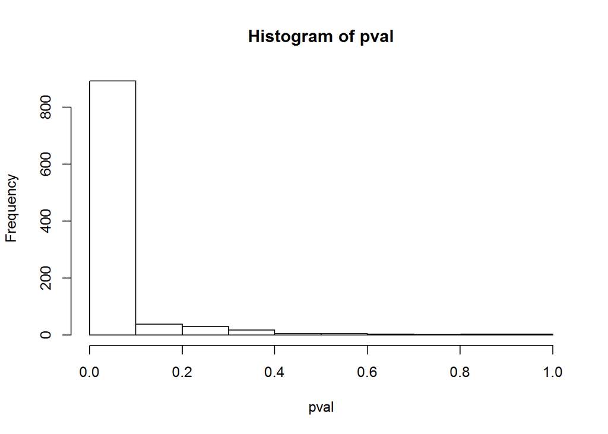

```r
# 1. Choose one fixed N
N <- 50

# 2. Select parameters
control = 7
treated = 5.6
alpha = 0.05


# 3. Simulate huge number of experiments and test
numberSimulation <- 1000
pval <- numeric(numberSimulation)

set.seed(1234) # set the seed for reproducible resuts
for (i in 1:numberSimulation){
  # we simulate from Poisson distribution
  controlGroup <- rpois(N, lambda = control)
  treatedGroup <- rpois(N, lambda = treated)
  # we use GLM model for Poisson regression to test effect of treatment
  simData <- data.frame(response = c(controlGroup, treatedGroup), treatment = rep(c(0,1),
                                                                                  each = N))
  pval[i] <- summary(glm(response ~ treatment, data = simData, family=poisson()))$coeff["treatment", "Pr(>|z|)"]
}
hist(pval)
```

```r
# Estimate power
sum(pval < 0.05)/numberSimulation
```

```
## [1] 0.822
```

We achieved power of 82.2% in this case. If required power would be 85%, we may need to increase `N` slightly and rerun the code.

### Design for more complex data set: Linear regression

Simulation approach gets more complicated, if we consider more complex statistical model and test. especially if covariance structure may play role, the simulation of data needs to be performed very carefully. However, the basic idea is always the same:

Let us assume model $outcome = \beta_0 + \beta_1*gender + \beta_2*country + \beta_3*age$. Let us say that we wish to mainly focus on effect of gender and effect size of interest is five, i.e. $\beta_1 = 5$.

We start with specifying the initial values for parameters. Be careful with meaning of specified sample size variable: if it refers to total sample size or per some group or combination of groups. See `n` below.

```r
Nsimulations <- 1000
n <- 10 # per gender+country
sdChoice <- 10
effectSize <- 5
```

We continue with creating the data set.

```r
gender <- rep(c(0,1), each = n*2)
country <- rep(rep(seq(0, 1), each = n), 2)
set.seed(1234)
age <- sample(seq(15, 50, by = 1), size = n*2*2, replace = TRUE)

# our structure so far
data.frame(gender = as.factor(gender), country = as.factor(country),  age = age)
```

```
##    gender country age
## 1       0       0  19
## 2       0       0  37
## 3       0       0  36
## 4       0       0  37
## 5       0       0  45
## 6       0       0  38
## 7       0       0  15
## 8       0       0  23
## 9       0       0  38
## 10      0       0  33
## 11      0       1  39
## 12      0       1  34
## 13      0       1  25
## 14      0       1  48
```

[output cut: 26 more lines]

Note that for age, we have taken random values between some range. In practice, you would often have good idea of age distribution in your population and you can simulate from such distribution.

Now we will establish deterministic mean value based on model specified above. Note that we can actually specify any value for other parameters, because as we see later, they do not have any influence on result for gender.

```r
meanResponse <- 5  + effectSize*gender - 2*country + 0.7* age

# we add response for each observation
data.frame(gender = as.factor(gender), country = as.factor(country),  age = age,
           meanResponse = meanResponse)
```

```
##    gender country age meanResponse
## 1       0       0  19         18.3
## 2       0       0  37         30.9
## 3       0       0  36         30.2
## 4       0       0  37         30.9
## 5       0       0  45         36.5
## 6       0       0  38         31.6
## 7       0       0  15         15.5
## 8       0       0  23         21.1
## 9       0       0  38         31.6
## 10      0       0  33         28.1
## 11      0       1  39         30.3
## 12      0       1  34         26.8
## 13      0       1  25         20.5
## 14      0       1  48         36.6
```

[output cut: 26 more lines]

Note that we have performed these steps outside of the loop, becuase there has not been any randomness so far. Adding the random error to the observations is the first step that needs to be performed within the loop.

```r
set.seed(1234)
pvaluesSim <- numeric(Nsimulations)
for (i in 1:Nsimulations){
  # simulated response is the mean response from model plus the random error
    response <- meanResponse + rnorm(length(meanResponse ), 0, sd = sdChoice)
    # the final data set used for each simulation step contains random error as well
    simulatedDataSet <- data.frame(gender = as.factor(gender), country = as.factor(country ),
        response = response, age = age)
    # keep the p-value for testing for gender
    pvaluesSim[i] <- summary(lm(response ~ gender + country + age, data = simulatedDataSet))$coeff["gender1",4]
}

# Estimate the power
sum(pvaluesSim < 0.05)/Nsimulations
```

```
## [1] 0.344
```

The estimated power is only 34.4%, so we will need to increase the `n` per group. Note that the result depends on `seed` specified above. Hence, it is important to track the seed and note that changing the seed may have small influence on reported result, in this case, we obtain 34.1%. How large the difference is indeed depends on amount of simulated data sets that we have used.

```r
set.seed(5678)
pvaluesSim <- numeric(Nsimulations)
for (i in 1:Nsimulations){
  # simulated response is the mean response from model plus the random error
    response <- meanResponse + rnorm(length(meanResponse ), 0, sd = sdChoice)
    # the final data set used for each simulation step contains random error as well
    simulatedDataSet <- data.frame(gender = as.factor(gender), country = as.factor(country ),
        response = response, age = age)
    # keep the p-value for testing for gender
    pvaluesSim[i] <- summary(lm(response ~ gender + country + age, data = simulatedDataSet))$coeff["gender1",4]
}

# Estimate the power
sum(pvaluesSim < 0.05)/Nsimulations
```

```
## [1] 0.341
```

Finally, let us check how we will change the if we change the parameters for other variables. There may be small difference even if same seed is used, becuase the data set is different in this case.

```r
gender <- rep(c(0,1), each = n*2)
country <- rep(rep(seq(0, 1), each = n), 2)
set.seed(1234)
age <- sample(seq(15,50,by=1), size = n*2*2, replace = TRUE)

# change the values of betas below:
meanResponse <- -3 + effectSize*gender - 0.1*country + 12* age
set.seed(1234)
pvaluesSim <- numeric(Nsimulations)
for (i in 1:Nsimulations){
  response <- meanResponse + rnorm(length(meanResponse ), 0, sd = sdChoice)
  simulatedDataSet <- data.frame(gender = as.factor(gender), country = as.factor(country ),
                                 response = response, age = age)
  pvaluesSim[i] <- summary(lm(response ~ gender + country + age, data = simulatedDataSet))$coeff["gender1", 4]
}
sum(pvaluesSim < 0.05)/Nsimulations
```

```
## [1] 0.344
```

Very important note is that statement above only hold if main effects solely are used. If there are interactions, the result depends both on variable of interest as on values of all related variables.